# Analysis of Lung Function Decline: Max quarterly 2 year observation cohort

Weiji Su, Enas Ghulam, Emrah Gecili, Eleni-Rosalina Andrinopoulou, Rhonda Szczesniak

April 09, 2019

| Model Name Abbreviation Name | Model Name Abbreviation Specification |
| --- | --- |
| Int | Linear evolution with random intercept |
| Int + Slope | Linear evolution with random intercept and slope |
| Spline | Non-linear evolution by using spline as both average evolution and random effect |
| Int + Corr | Linear evolution with random intercept and exponential correlation structure |
| Spline + Corr | Non-linear evolution with spline as average evolution, random intercept and exponential correlation structure |
| Lin_GEE | Linear evolution with independence correlation structure |
| Nonlin_GEE | Non-linear evolution by using spline with independence correlation structure |

# 1 Model Comparison using AIC and BIC

We compare all models including LME model by using AIC and BIC. Note that these criterion cannot be used to evaluate fit for the GEE and joint models.

|  | df | AIC | BIC |
| --- | --- | --- | --- |
| Int | 5 | 1293024 | 1293074 |
| Int + Slope | 7 | 1292057 | 1292127 |
| Spline | 16 | 1286861 | 1287022 |
| Int + Corr | 7 | 1285085 | 1285156 |
| Spline + Corr | 12 | 1283245 | 1283365 |

For the GEE model, the criterion Quasi-AIC, known as QIC, is used to compare GEE type models, since GEE model estimation is based on quasi-likelihood; by contrast, the LME models reported here are estimated based on a specified likelihood. The QIC for linear and nonlinear GEE models are below.

| Model | QIC |
| --- | --- |
| Lin_GEE | 1055471 |
| Nonlin_GEE | 1046817 |

# 2 Model Comparison using MAD, RMSE and Correlation

The following model shows Median Absolute Deviation (MAD), Root-mean-square deviation (RMSD) and correlation of observations (FEV1) and fitted value. For MAD and RMSE, the smaller the better model; for Corr (correlation), the larger the better model.

|  | MAD | RMSE | Corr |
| --- | --- | --- | --- |
| Int | 3.470 | 7.214 | 0.964 |
| Int + Slope | 3.455 | 7.206 | 0.964 |
| Spline | 3.225 | 6.715 | 0.969 |
| Int + Corr | 4.910 | 7.477 | 0.974 |
| Spline + Corr | 4.707 | 7.261 | 0.974 |

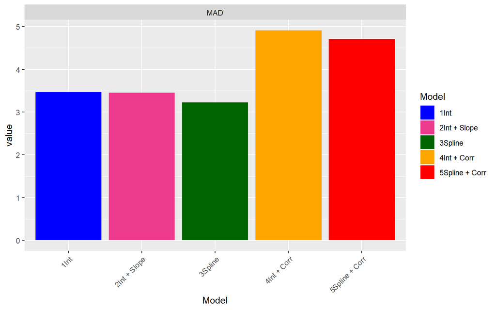

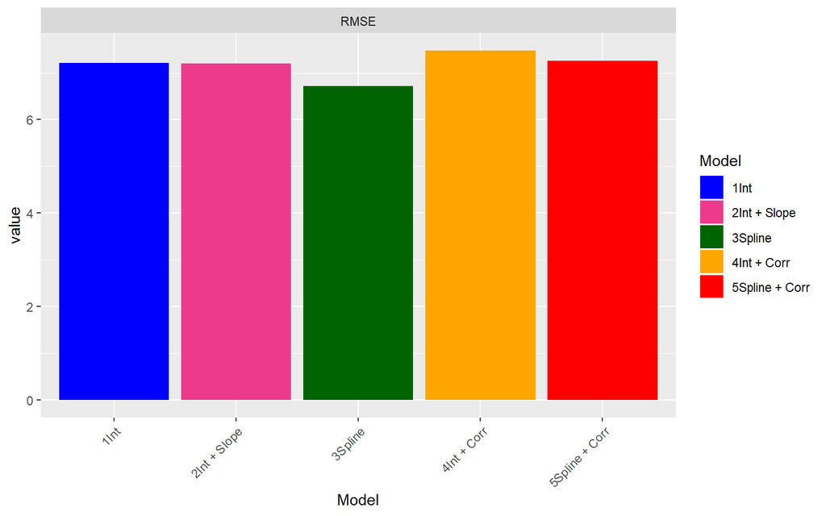

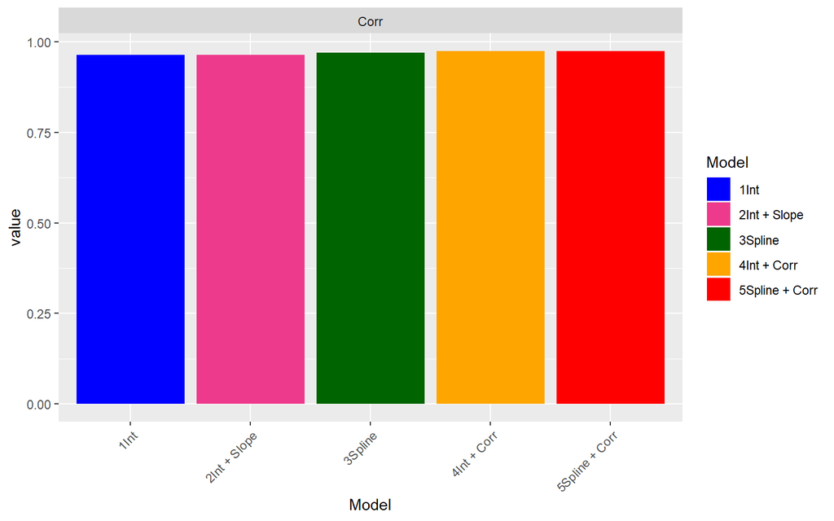

# 3 Plot Observation and Estimated Evolution

Here we recall the estimation of population-level evolution by different models we have presented.

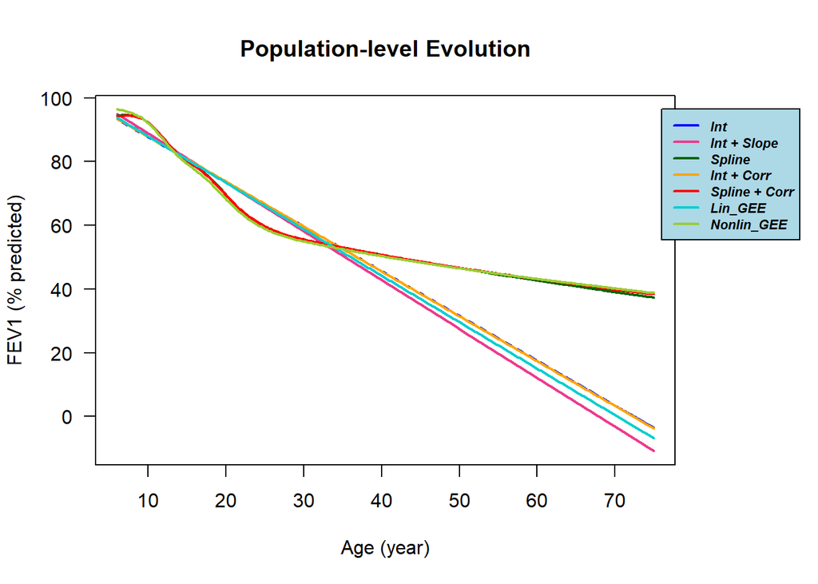

Here we are showing the patient-specific evolution by different models. We randomly select 8 subjects from the sample and show the subject’s FEV1 from observations (black points) with estimation from models (color curves). The following figures for subject 916590758, 924330796, 927710764, 954270618, 963270660, 965570728, 974110732, 976610718.

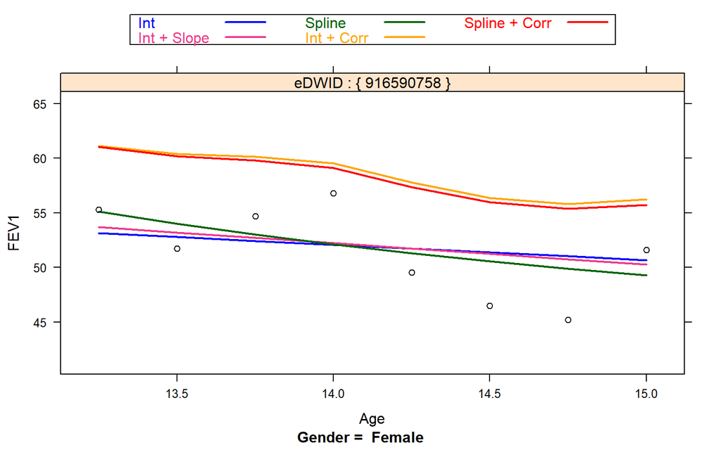

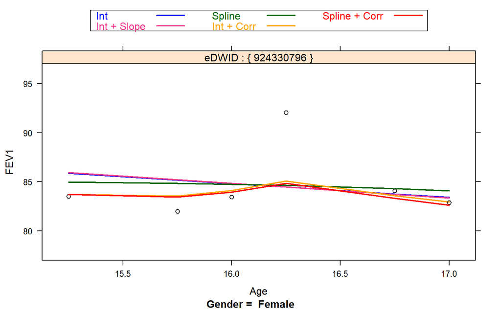

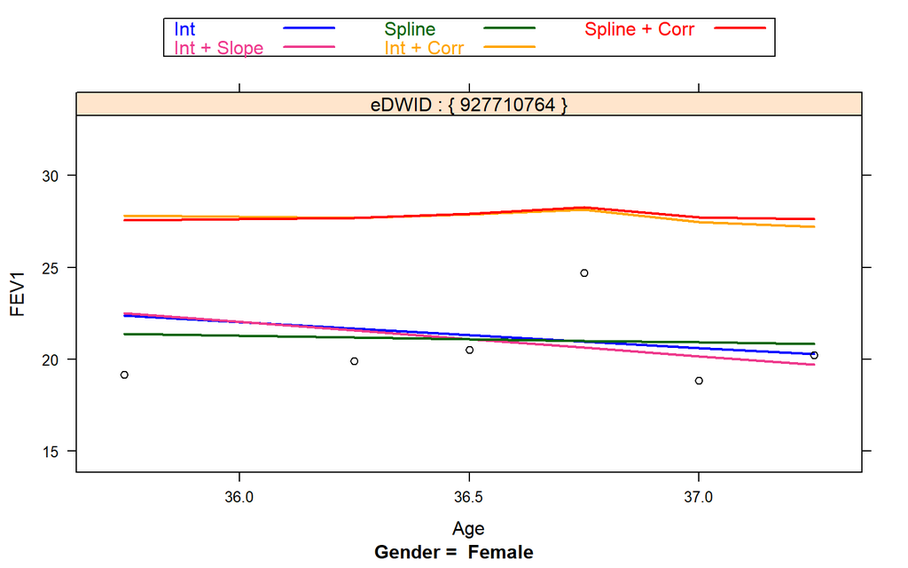

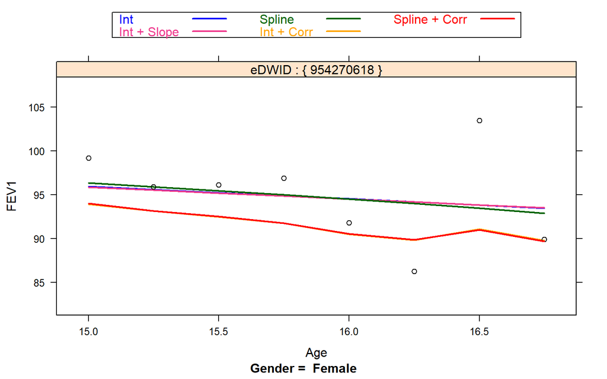

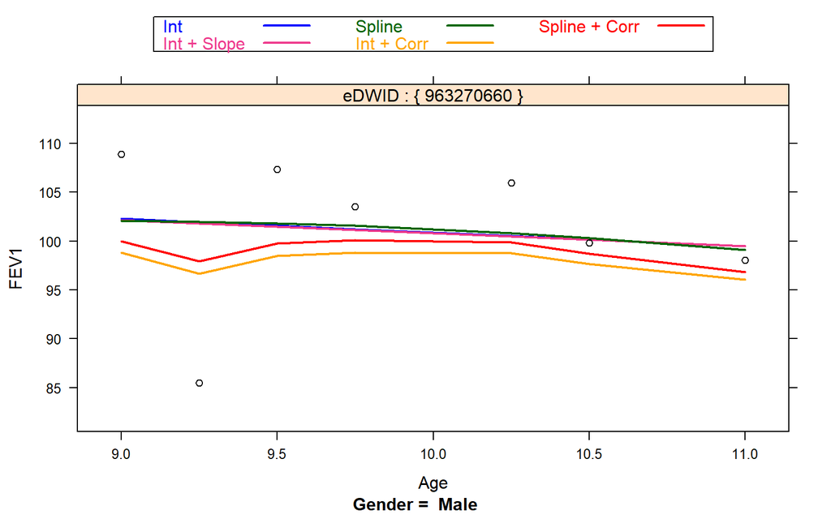

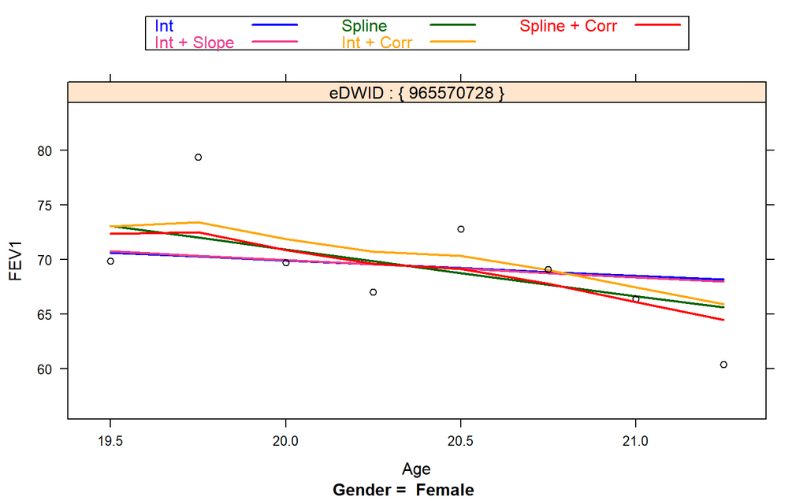

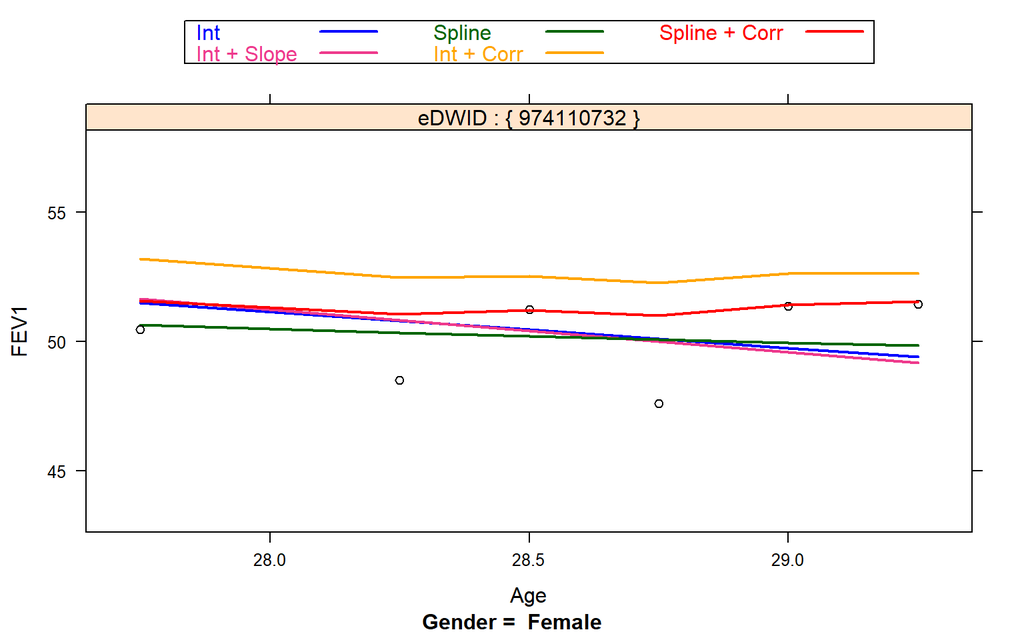

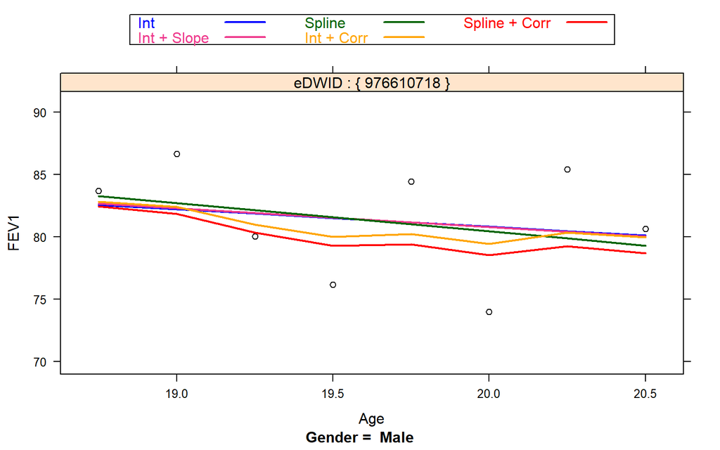